# ML1.Extra.Credit

Jaclyn A Coate

2020-08-09

# Extra Credit Summer 2020: Forecasting Texas New Covid Cases

## EDA

### Train Data load:

```r
train <- read.csv("https://raw.githubusercontent.com/JaclynCoate/7331_MachineLearning1/master/ExtraCredit/traindaily.csv", header = T)
head(train)
```

```
##       date state positive positiveIncrease
## 1 20200706    TX   200557             5318
## 2 20200705    TX   195239             3449
## 3 20200704    TX   191790             8258
## 4 20200703    TX   183532             7555
## 5 20200702    TX   175977             7915
## 6 20200701    TX   168062             8076
```

```r
train <- transform(train, date = as.Date(as.character(date), "%Y%m%d"))
train = train[order(as.Date(train$date, format = "%Y%m%d")),]
head(train)
```

```
##           date state positive positiveIncrease
## 125 2020-03-04    TX        1                0
## 124 2020-03-05    TX        1                0
## 123 2020-03-06    TX        5                4
## 122 2020-03-07    TX        8                3
## 121 2020-03-08    TX        8                0
## 120 2020-03-09    TX       12                4
```

### Test Data Load:

```r
test <- read.csv("https://raw.githubusercontent.com/jakemdrew/CoronaCurves/master/Corona_MAE.csv", header = T)
head(test)
```

```
##     TX.Date Curve_Day TX.New.Cases
## 1  7/7/2020        19         9828
## 2  7/8/2020        20        10649
## 3  7/9/2020        21        11901
## 4 7/10/2020        22        10554
## 5 7/11/2020        23         8674
## 6 7/12/2020        24         6363
```

### N/A Evaluation:

```r
train[is.na(train)] <- 0
tail(train)
```

```
##         date state positive positiveIncrease
## 6 2020-07-01    TX   168062             8076
## 5 2020-07-02    TX   175977             7915
## 4 2020-07-03    TX   183532             7555
## 3 2020-07-04    TX   191790             8258
## 2 2020-07-05    TX   195239             3449
## 1 2020-07-06    TX   200557             5318
```

### Realization, ACF, Spectral Density Evluation

- Actual Realization

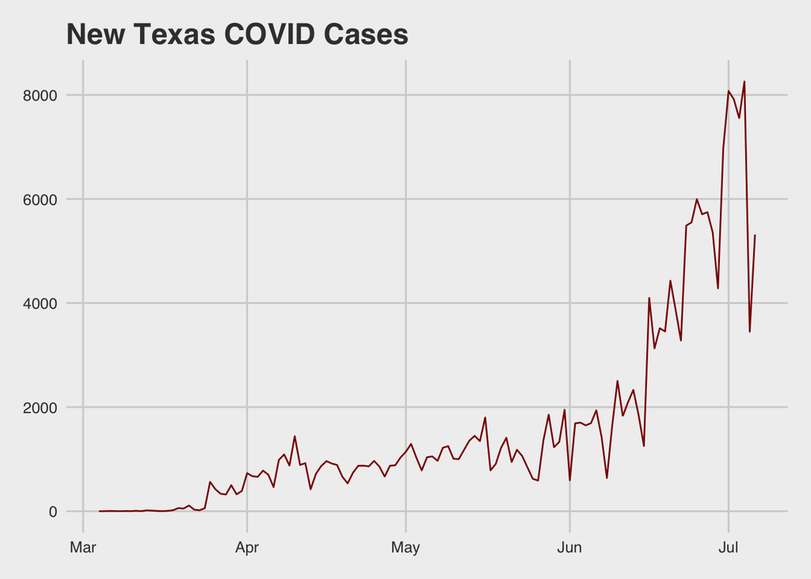

```r
ggplot(data = train, aes(x=date, y=positiveIncrease))+
  geom_line(color="dark red")+
  labs(title = "New Texas COVID Cases", y = "Thousands", x = "") +
  theme_fivethirtyeight()
```

- Sample Realization, ACF, Spectral Density
  - Realization: heavy wandering and pseudo cyclic behavior
  - ACF: Slowly dampening and what appears to be a slight seasonal componenet rising
  - Spectral Density: f = 0, and f = .28 indicative of a period = 3.5

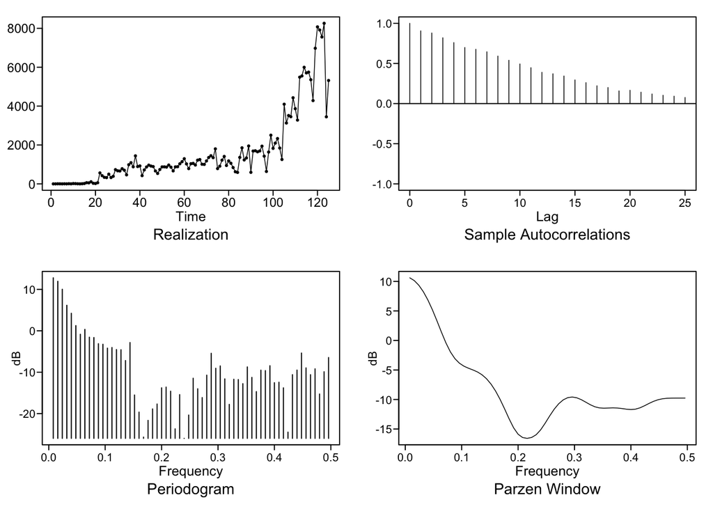

```
## $autplt
##  [1] 1.00000000 0.90636287 0.87967094 0.82002812 0.76003356 0.69890529
##  [7] 0.67683921 0.64547601 0.59203818 0.53989539 0.49393286 0.44729129
## [13] 0.39004363 0.37155406 0.34394906 0.29483771 0.26125642 0.22186505
## [19] 0.20063657 0.15850040 0.16619075 0.14229632 0.12007443 0.10357713
## [25] 0.09250727 0.07599149
##
## $freq
##  [1] 0.008 0.016 0.024 0.032 0.040 0.048 0.056 0.064 0.072 0.080 0.088
## [12] 0.096 0.104 0.112 0.120 0.128 0.136 0.144 0.152 0.160 0.168 0.176
## [23] 0.184 0.192 0.200 0.208 0.216 0.224 0.232 0.240 0.248 0.256 0.264
## [34] 0.272 0.280 0.288 0.296 0.304 0.312 0.320 0.328 0.336 0.344 0.352
## [45] 0.360 0.368 0.376 0.384 0.392 0.400 0.408 0.416 0.424 0.432 0.440
## [56] 0.448 0.456 0.464 0.472 0.480 0.488 0.496
##
```

[output cut: 29 more lines]

```r
plotts.sample.wge(train$positiveIncrease)
```

### Transformations

- Single transformation to accound for heavy wandering and what appears to be a (1-B) component
  - We see much stationarized data however have surface a seasonality componentn of 7, seeing spikes in the ACF at 7, 14, 21 etc.

```r
train.diff = artrans.wge(train$positiveIncrease, phi.tr = 1)
```

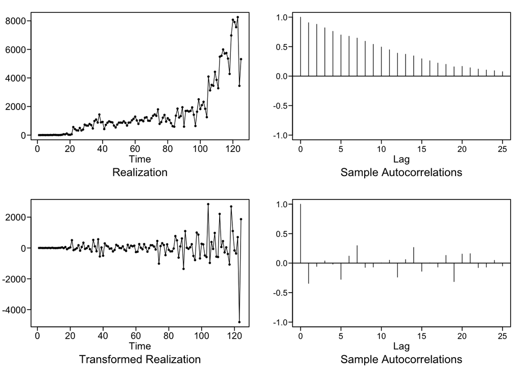

- Seasonality Transformation
  - Above we have surfaced what appears to be a 7-day seasonality trend. We will now transform the data for the s=7.

```r
train.diff.seas = artrans.wge(train.diff,phi.tr = c(0,0,0,0,0,0,1))
```

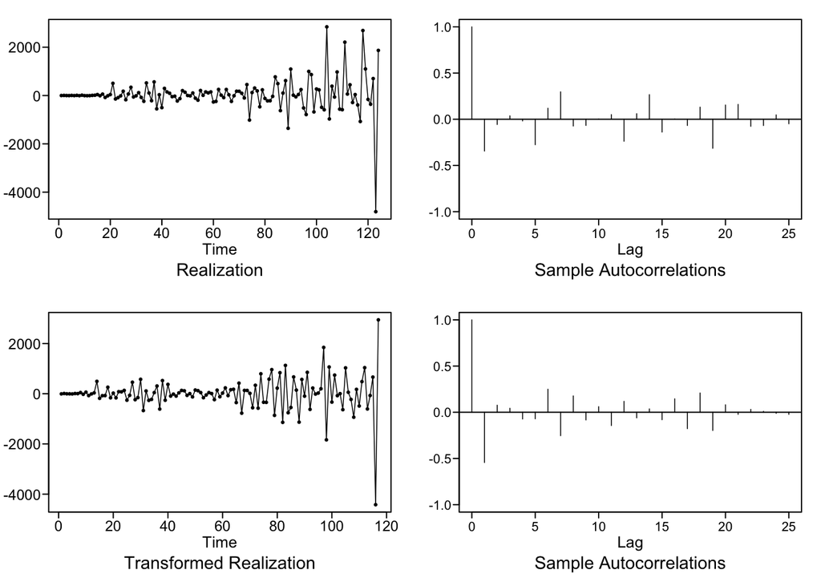

### Diagnose Model

- Using AIC5.wge we diagnose the data for the best fit model using AIC and BIC.
  - AIC: ARMA(5,1)
  - BIC: MA(1)

```r
aic5.wge(train.diff.seas)
```

```
## ---------WORKING... PLEASE WAIT...
##
##
## Five Smallest Values of  aic
```

```
##       p    q        aic
## 17    5    1   12.55829
## 18    5    2   12.57538
## 16    5    0   12.60750
## 5     1    1   12.63957
## 2     0    1   12.64090
```

```r
aic5.wge(train.diff.seas,type = "bic")
```

```
## ---------WORKING... PLEASE WAIT...
##
##
## Five Smallest Values of  bic
```

```
##       p    q        bic
## 2     0    1   12.68812
## 5     1    1   12.71040
## 3     0    2   12.71218
## 7     2    0   12.71794
## 17    5    1   12.72354
```

- White noise evaluation
  - We have confirmed this not white noise and will need to be modeled appropriately.

```r
ljung.wge(train.diff.seas)$pval
```

```
## Obs -0.5440482 0.07672473 0.04333539 -0.07325823 -0.0711314 0.2498934 -0.2537502 0.1768845 -0.08335458 0.06080848 -0.1437344 0.1184816 -0.06085621 0.03651343 -0.08106978 0.1458005 -0.1773083 0.2087676 -0.1970128 0.08092424 -0.02280624 0.03146829 0.0101351 -0.01186033
```

```
## [1] 8.172475e-09
```

```r
ljung.wge(train.diff.seas, K=48)$pval
```

```
## Obs -0.5440482 0.07672473 0.04333539 -0.07325823 -0.0711314 0.2498934 -0.2537502 0.1768845 -0.08335458 0.06080848 -0.1437344 0.1184816 -0.06085621 0.03651343 -0.08106978 0.1458005 -0.1773083 0.2087676 -0.1970128 0.08092424 -0.02280624 0.03146829 0.0101351 -0.01186033 -0.02285561 0.01791591 -0.080…
```

```
## [1] 4.794004e-08
```

- We choose to model both for best NN MSE: Phis and Thetas

```r
est.train.diff.seasAIC = est.arma.wge(train.diff.seas, p = 5, q=1)
```

```
##
## Coefficients of Original polynomial:
## -1.3961 -0.9284 -0.4841 -0.4245 -0.4186
##
## Factor                 Roots                Abs Recip    System Freq
## 1+0.9646B             -1.0367               0.9646       0.5000
## 1+1.1594B+0.8382B^2   -0.6916+-0.8454i      0.9156       0.3591
## 1-0.7278B+0.5177B^2    0.7029+-1.1989i      0.7195       0.1656
##
##
```

```r
mean(train$positiveIncrease)
```

```
## [1] 1604.448
```

```r
est.train.diff.seasBIC = est.arma.wge(train.diff.seas, q=1)
est.train.diff.seasBIC
```

```
## $phi
## [1] 0
##
## $theta
## [1] 0.705885
##
## $res
##   [1]    -2.6461351    -0.6456448   -12.2335287   -21.4132417   -31.8930631
##   [6]   -22.2906115   -19.5123852    24.4487229   -14.5197919    43.9729194
##  [11]   -50.7379552   -52.5929374   -11.9023415   476.8205384   144.8026704
##  [16]    15.4362499   -70.8815611   200.1879941   -30.4680829    -6.2847394
##  [21]  -177.2140808   -50.8705327    31.3134781   146.3259356  -162.4885001
##  [26]  -186.4759667   317.5916413   -21.5946137  -179.0210909   439.8539261
##  [31]  -368.2915053  -157.7492135  -383.1305756  -505.2238900  -320.4077249
##  [36]    74.0512271  -567.5061300   114.6281784  -186.8634702   232.3181084
##  [41]    62.2120816    20.1367952   -87.5635168   -36.5875477    97.3956225
##  [46]   176.9723276    52.1443272    33.0301187  -111.4623136    60.5426511
##  [51]   155.9583692   147.3108900   -62.7932356  -103.1025786   -36.5563377
##  [56]   -27.5823469  -263.2477417   -52.6004003  -164.9076094  -100.1835796
##  [61]   153.5041398    25.5784863   169.2776911   288.7127990  -156.9797543
##  [66]   302.4125742  -569.3092890  -277.6446443   -73.7629574   -44.8459402
##  [71]  -599.4338526   -94.9091209  -650.7726991   326.8515594  -118.0581767
##  [76]  -436.1132695   263.3764230  1137.1356789   -67.0908008   166.8638347
##  [81]   947.0088941  -480.2984393   781.1867760  -214.3497791  -708.0840637
##  [86]   160.3963289   249.4435790  -964.6993062  -120.7445121  -190.0095133
##  [91]   709.0973639  -132.2366111   124.8783869    66.3719977    65.0732174
##  [96]   235.1564279  2002.2156087  -431.4438863   751.6724704   188.8165164
## [101]   866.5049620   526.8750455   366.1353944  -385.3283084   750.2247634
## [106]   578.7946018   172.7846285  -822.8117066  -415.5881891  -790.1352314
## [111]   -83.5223566   971.2650466    70.8236140   -29.7844536   633.1978243
## [116] -3980.8129548   124.2262157
##
## $avar
## [1] 298557.1
##
## $aic
## [1] 12.6409
##
## $aicc
## [1] 13.65981
##
## $bic
## [1] 12.68812
##
## $se.phi
## [1] 0
##
## $se.theta
## [1] 0.004531644
```

## Univariate ARIMA(5,1,1), s=7 Forecasting

- Forecast for ARIMA(5,1,1), s = 7

```r
arima5.1.Fore <- fore.aruma.wge(train$positiveIncrease, phi = est.train.diff.seasAIC$phi, theta = est.train.diff.seasAIC$theta, d = 1, s = 7, n.ahead = 32, lastn = F, limit = T)
```

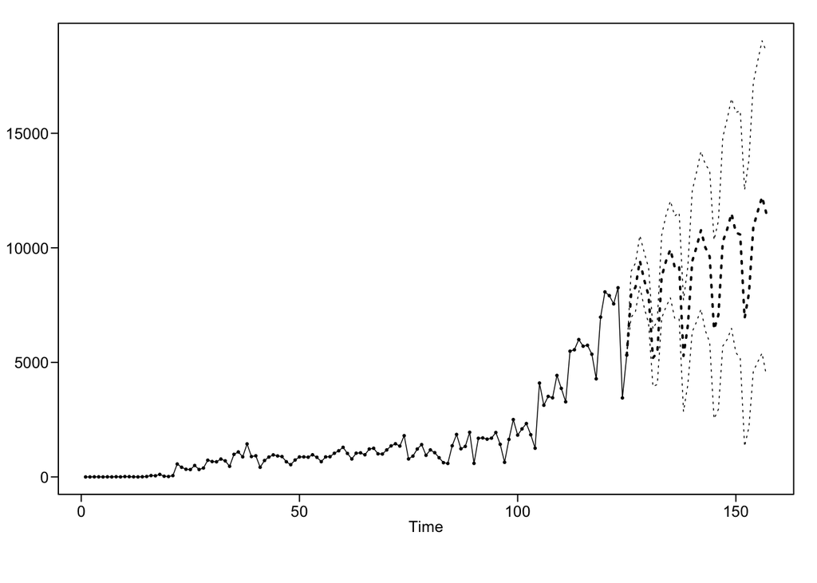

- Predicted versus Actual for ARIMA(5,1,1), s = 7

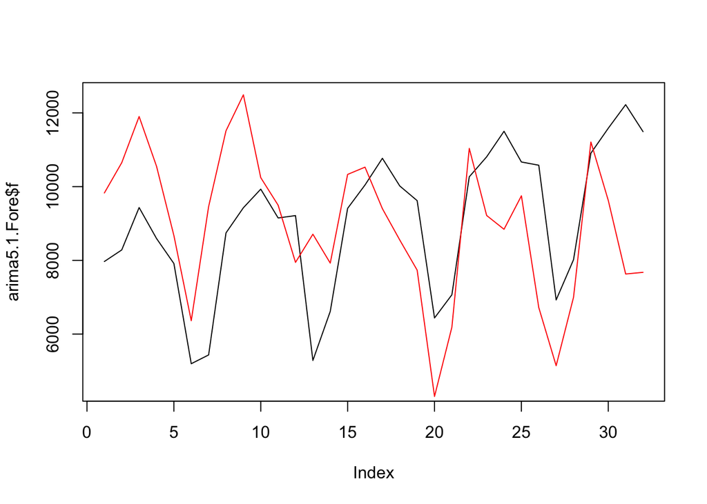

```r
plot(arima5.1.Fore$f, type = "l", ylim = c(4500, 12500))
lines(test$TX.New.Cases, col = "red")
```

- Mean Absolute Error for Forecast for ARIMA(5,1,1), s = 7

```r
mae.5.1 = mean(abs(arima5.1.Fore$f - test$TX.New.Cases))
mae.5.1
```

```
## [1] 1859.352
```

### Univariate ARIMA(0,1,1), s=7 Forecasting

```r
arima0.1Fore <- fore.aruma.wge(train$positiveIncrease, phi = 0, theta = .705885, d = 1, s = 7, n.ahead = 32, lastn = F, limit = T)
```

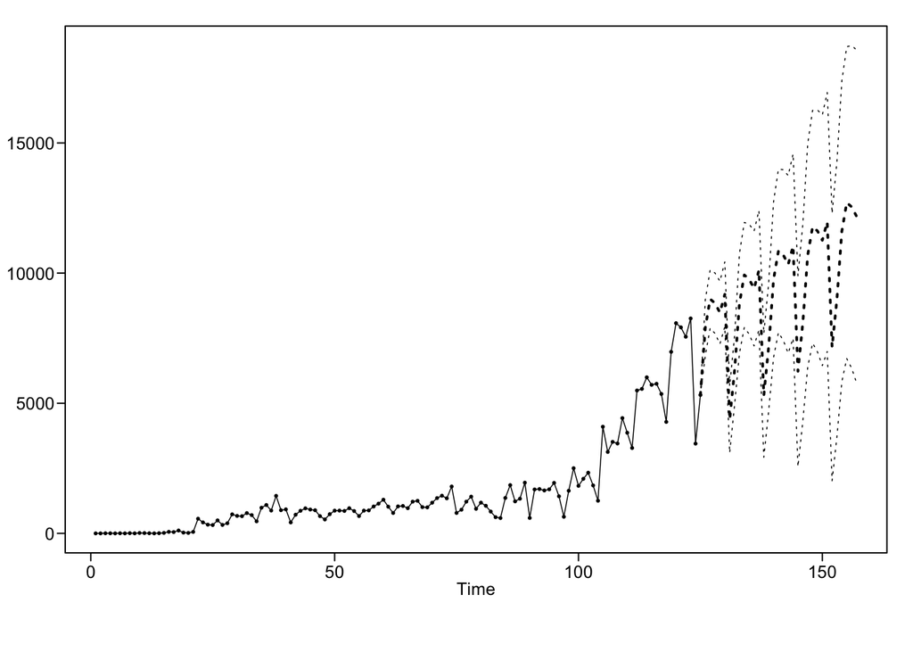

- Predicted versus Actual for ARIMA(0,1,1), s = 7

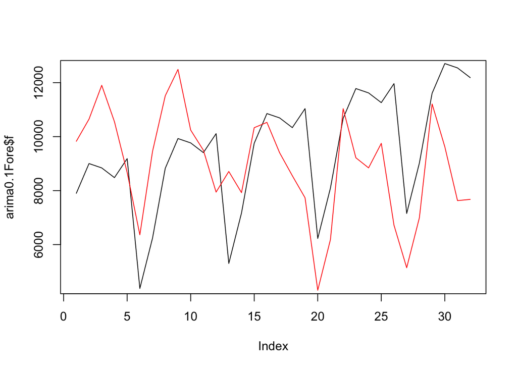

```r
plot(arima0.1Fore$f, type = "l", ylim = c(4500, 12500))
lines(test$TX.New.Cases, col = "red")
```

- Mean Absolute Error for Forecast for ARIMA(0,1,1), s = 7

```r
mae.0.1 = mean(abs(arima0.1Fore$f - test$TX.New.Cases))
mae.0.1
```

```
## [1] 2095.586
```

### Univariate Hypertuned Neural Network Model

- Hyper tune parameters
  - Here we are running specialty function contained in tswgewrapped package that allows us to perform a grid search that will complete the tuning of all parameters to obtain the one with the lowest windowed M/ASE.

```r
set.seed(2)
nntrain <- data.frame(positiveIncrease = train$positiveIncrease, xx = rnorm(125, 0, .0001))
nntest <- data.frame(TX.New.Cases = test$TX.New.Cases, xx = rnorm(32, 0, .0001))
```

```r
# search for best NN hyperparameters in given grid
nnmodeltune = tswgewrapped::ModelBuildNNforCaret$new(data = nntrain, var_interest = "positiveIncrease",
                                               search = 'random', tuneLength = 5, parallel = TRUE,
                                               batch_size = 50, h = 7, m = 7,
                                               verbose = 1)
```

```
## - Total Time for training: : 43.715 sec elapsed
```

- The windowed mean squared errors associated with the grid of hyperparameters is shown in the table and heatmap below.

```r
res <- nnmodeltune$summarize_hyperparam_results()
res
```

```
##   reps hd allow.det.season     RMSE      ASE   RMSESD    ASESD
## 1   10  2             TRUE 545.4213 449280.5 408.6266 545029.1
## 2   11  3            FALSE 532.4174 418130.0 384.8739 500125.0
## 3   16  1            FALSE 661.6696 704295.2 541.4217 869464.1
## 4   16  3             TRUE 531.7720 420650.9 389.4309 504421.2
## 5   22  3            FALSE 528.3605 409245.3 378.2704 478577.3
```

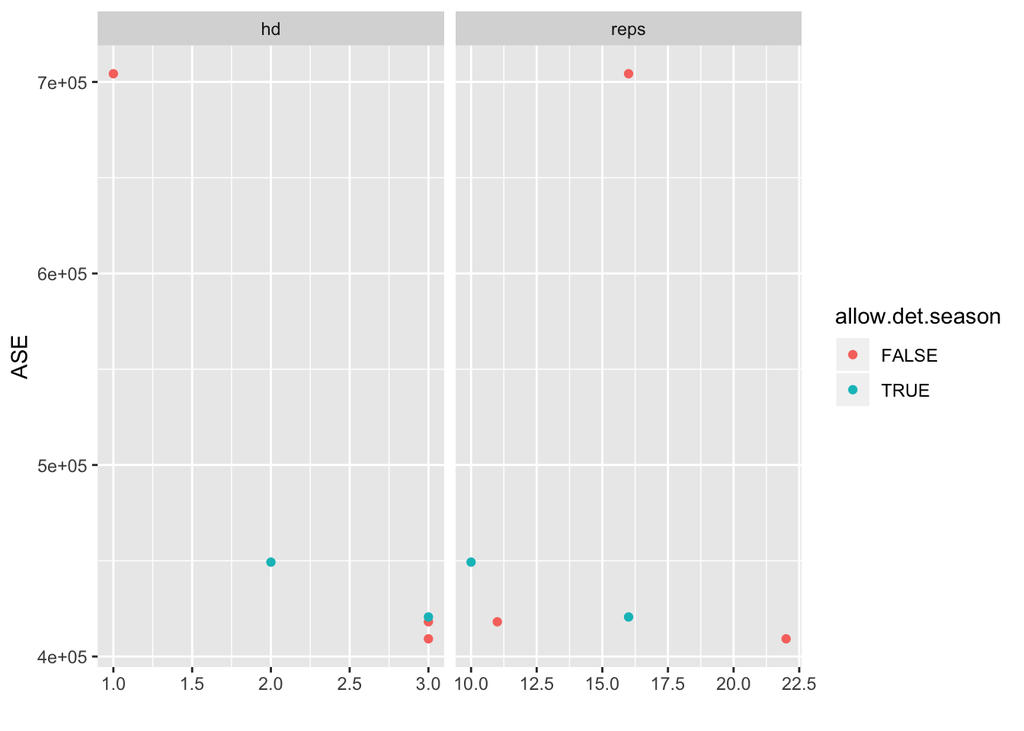

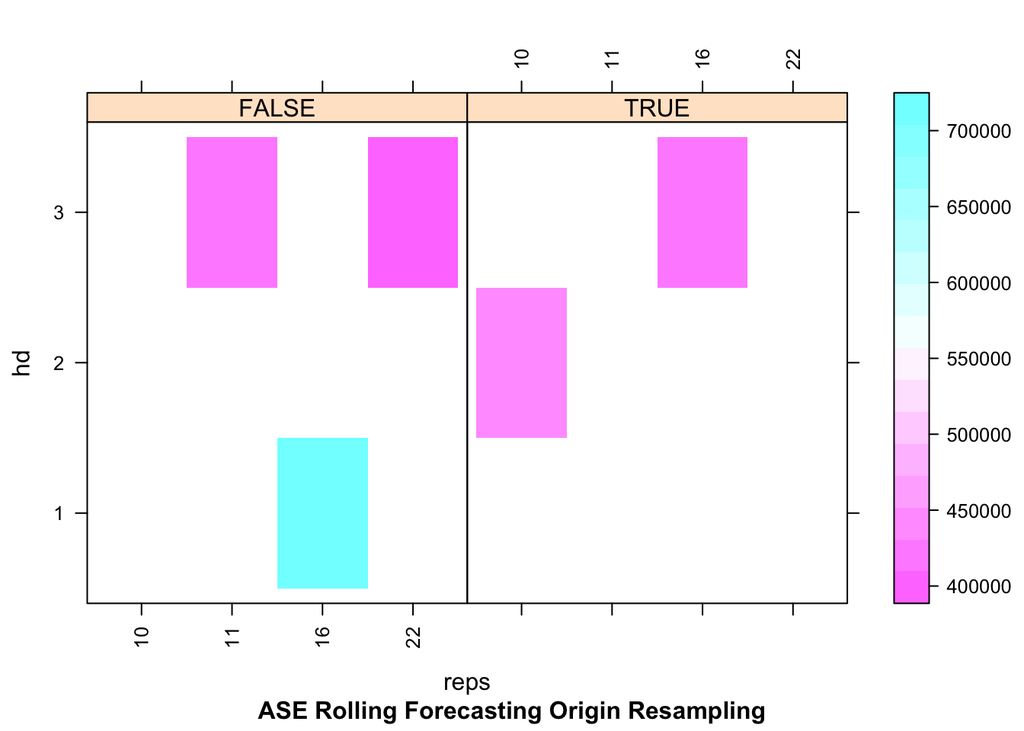

```r
nnmodeltune$plot_hyperparam_results()
```

- Best Parameters shown in below table. The best hyperparameters based on this grid search are listed below

```r
best <- nnmodeltune$summarize_best_hyperparams()
best
```

```
##   reps hd allow.det.season
## 5   22  3            FALSE
```

- NN Windowed RMSE is below.

```r
final.rmse <- dplyr::filter(res, reps == best$reps &
                    hd == best$hd &
                    allow.det.season == best$allow.det.season)[['RMSE']]
final.rmse
```

```
## [1] 528.3605
```

- NN Modell Characteristics and MSE:

```r
# Ensemble / Hypertuned NN Model
caret_model = nnmodeltune$get_final_models(subset = 'a')
caret_model$finalModel
```

```
## MLP fit with 3 hidden nodes and 22 repetitions.
## Univariate lags: (1,2,3)
## Forecast combined using the median operator.
## MSE: 317656.9229.
```

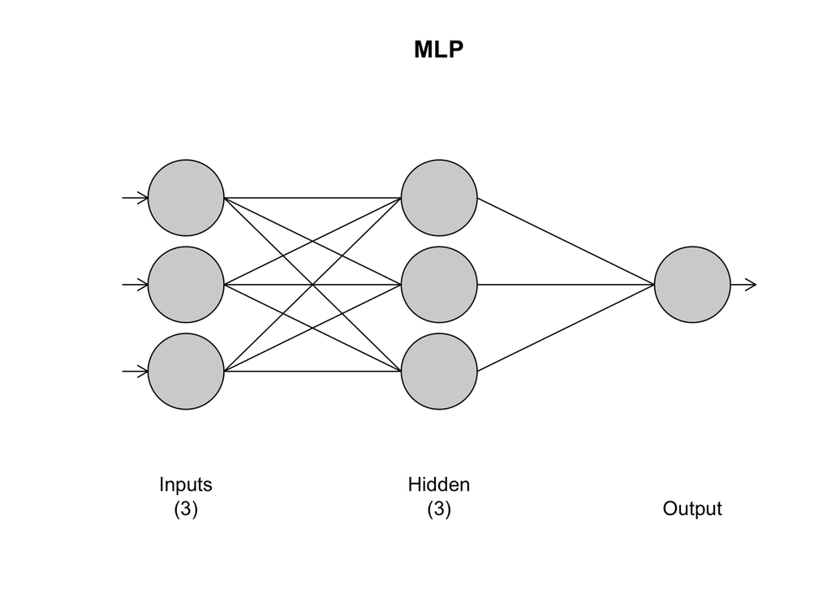

```r
#Plot Final Model
plot(caret_model$finalModel)
```

- Fit trian data on best model parameters

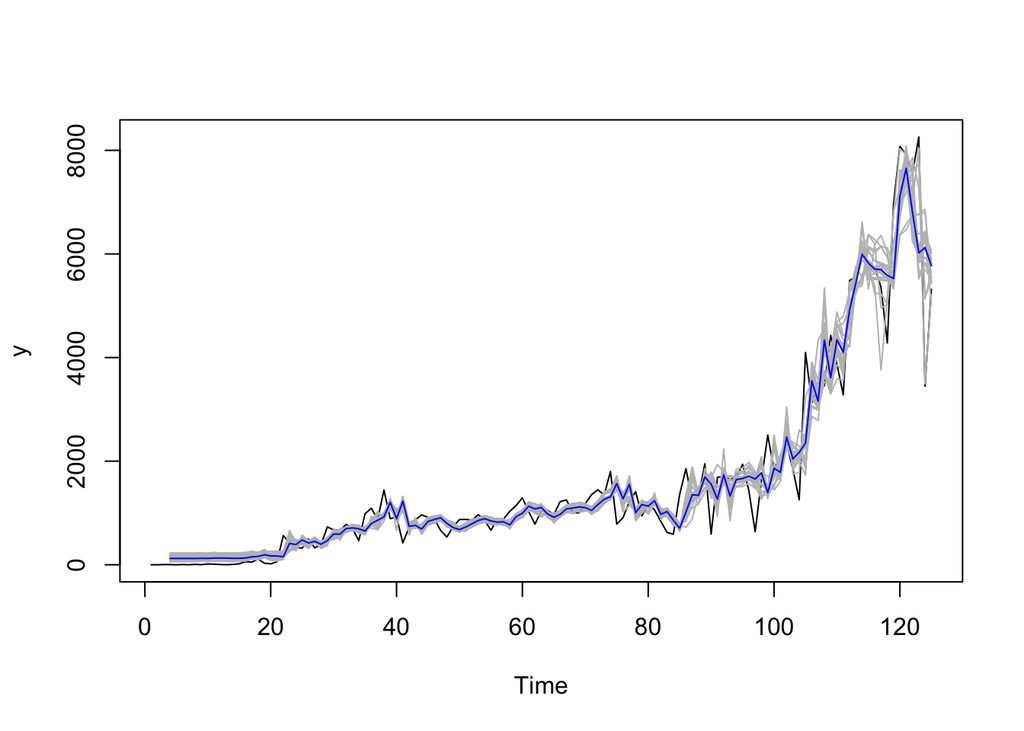

```r
set.seed(2)
nnmodel = mlp(ts(train$positiveIncrease), outplot = T, reps = 22, hd = 3, allow.det.season = F)
```

```r
nnmodel
```

```
## MLP fit with 3 hidden nodes and 22 repetitions.
## Univariate lags: (1,2,3)
## Forecast combined using the median operator.
## MSE: 279764.086.
```

- NN Forecasts

```r
fore32.nnmodel = forecast(nnmodel, h=32)
```

- Plotting NN Forecasts

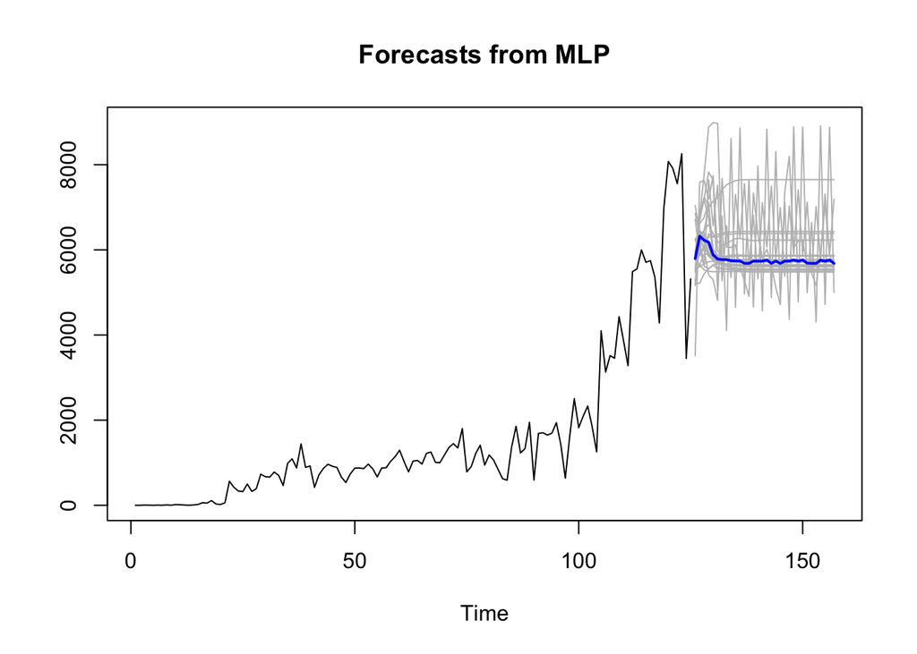

```r
plot(fore32.nnmodel)
```

- Ploting NN Predictions versus Actual

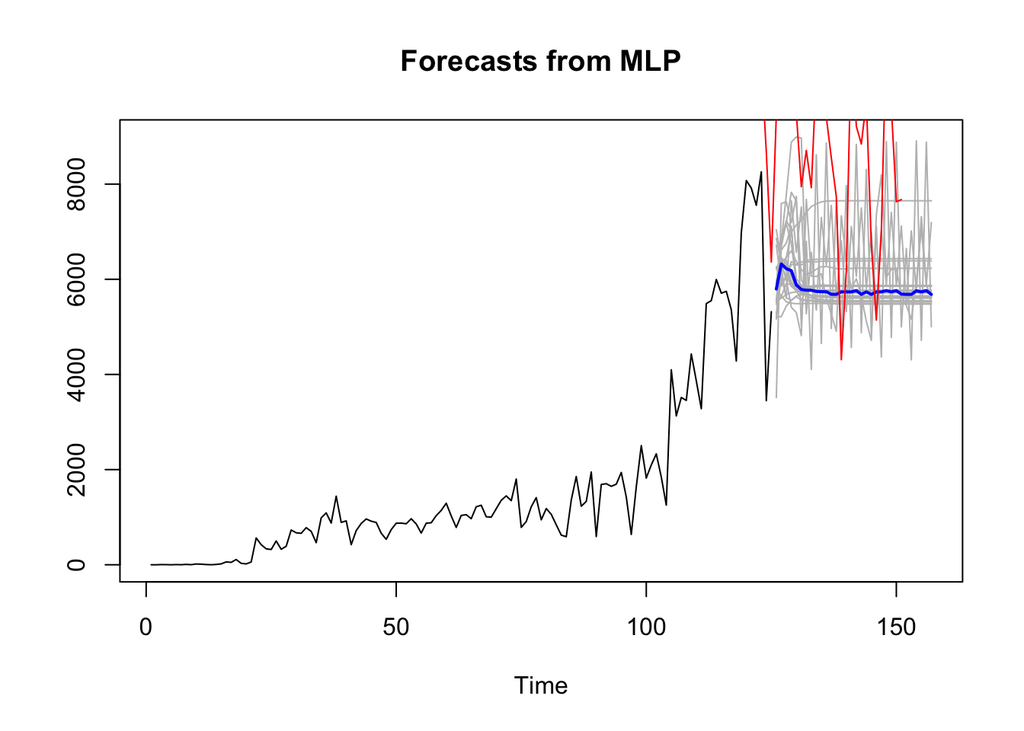

```r
plot(fore32.nnmodel, ylim = c(0, 12500))
lines(seq(120,151), test$TX.New.Cases, type = "l", col = "red")
```

- NN: Mean Absolute Error

```r
nnMAE = mean(abs(fore32.nnmodel$mean - test$TX.New.Cases))
nnMAE
```

```
## [1] 3292.661
```

## Final Model Comparison

### Univariate ARIMA(5,1,1), s = 7

- MAE: 1859.352

### Univariate ARIMA(0,1,1), s = 7

- MAE: 2095.586

### Hyper Tuned MLP

- MAE: 3292.661